# test

Nicholas Nagle

January 26, 2015

# INSTRUCTIONS:

Edit this file by replacing the instructions with text and code to anser the questions. I should be able to knit this file and reproduce the html, pdf, or word document.

A block to load in the data:

```r
rm(list=ls()) # Clean the workspace to be empty
arbuthnot <- read.csv('/Users/nnagle/Dropbox/git_root/homework/homework1/data/arbuthnot.csv')
```

# Question 1

This is a question about how the axes affects how we interpret plots.

Create two plots of Male-Female Christenings, one in which the y-axis scale is set by default, and one in which the y-axis extends all the way to zero. Yes, I know that was in the tutorial. I want to see it here.

- Describe the visual appearance of the two plots. Do they “feel” like they describe the same data?
- Describe how you might be able to mislead readers by changing the scaling on graphs.
- Which plot seems more appropriate here? Why?

# Question 2

This question is designed to give you some practice with ggplot as well as describing plots in words.

Use ggplot to create a scatterplot that has Female christenings on the x-axis and Male christenings on the y-axis. Draw a 45 degree line (using geom_abline) to show the line where Male and Female christenings are equal. Use this figure to describe the relationship and distribution of Male and Female christenings.

# Question 3

This is a question about population, sample, representativeness and generalizability.

How do you think the christenings-based sample would compared to a births-based sample? Similar? Different? Why? Arbuthnot’s data probably included most every christening in London during this period; they probably aren’t any unreported christenings. Is this fact important? Why or why not? Would a christenings based sample be appropriate now, in the 21st century? (Hint, this last question is trickier than it might seem. Think about what causes Male/Female Births, what causes people to christen their children, and any relations or not between these)

```r
rm(list=ls()) # Clean the workspace to be empty
library(ggplot2)
arbuthnot <- read.csv('/Users/ingrama/documents/GEOG415/arbuthnot.csv')
```

# Question 1

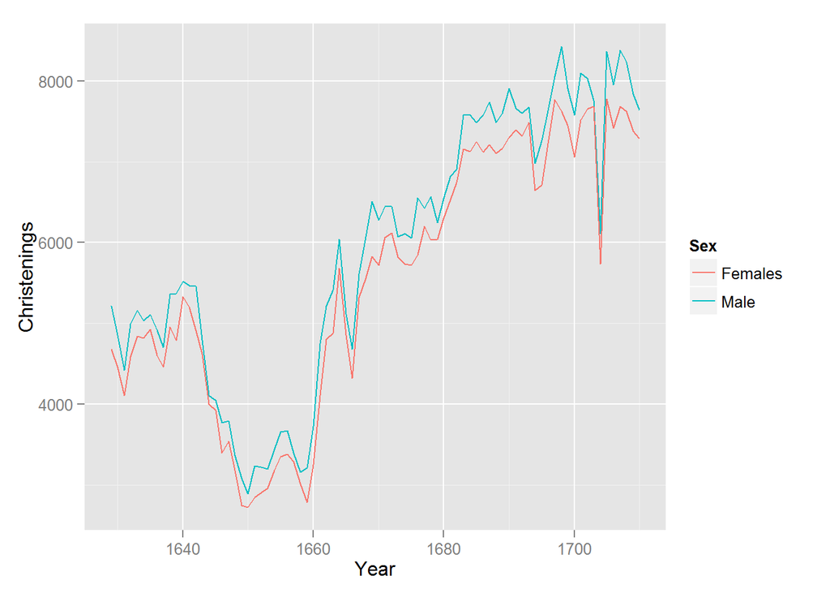

```r
 ggplot(data=arbuthnot) +
     geom_line(aes(x=Year, y=Males, color='Male')) +
     geom_line(aes(x=Year, y=Females, color='Females')) +
     ylab('Christenings') + labs(color='Sex')
```

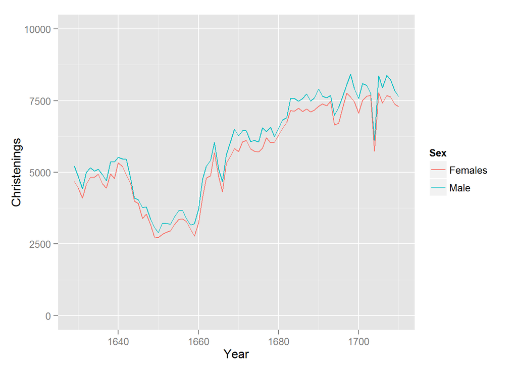

```r
ggplot(data=arbuthnot) +
  geom_line(aes(x=Year, y=Males, color='Male')) +
  geom_line(aes(x=Year, y=Females, color='Females')) +
  scale_y_continuous(limits=c(0, 10000)) +
  ylab('Christenings') + labs(color='Sex')
```

- Describe the visual appearance of the two plots. Do they “feel” like they describe the same data?

The y-axis appears vertically exaggerated in the first plot, showing the data more zoomed in and detailed. They do feel like they describe the same data, however, the decrease in christenings is much more pronounced in the first graph.

- Describe how you might be able to mislead readers by changing the scaling on graphs.

You can mislead readers by changing the scaling on the graph, such as with the first graph, because it appears to have a drastic decrease in christenings from 1640 to 1660, but in the second graph it doesn’t look like as much. Readers may not know the y-axis does not go down to 0 in the first plot just by glancing at it and assume the decrease is much more than it really is.

- Which plot seems more appropriate here? Why?

I think it is more appropriate to use the second plot with the y-axis from 0 to 10,000. While there was a decrease from 1640 to 1660, it was not as drastic as the first graph makes it appear.

# Question 2

Use this figure to describe the relationship and distribution of Male and Female christenings.

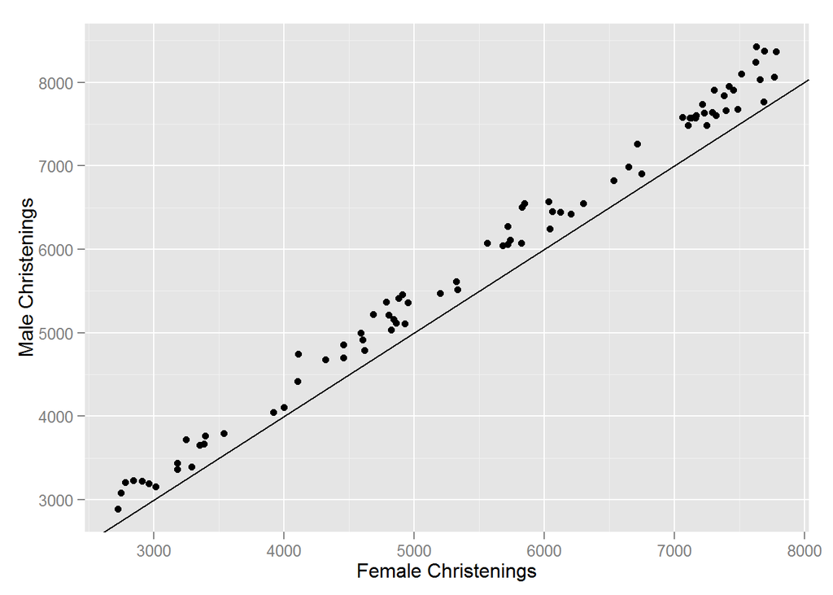

```r
ggplot(data=arbuthnot)+geom_point(aes(x=Females, y=Males))+ ylab('Male Christenings')+ xlab('Female Christenings')+geom_abline(intercept=0, slope=1)
```

There were more male christenings than female christenings. The 45 degree line has a slope of +1 and a y-intercept of 0. This is the line where male and female christenings would be equal. The dots are above the line showing that there were more male christenings. It is not equal with male and female christenings.

# Question 3

How do you think the christenings-based sample would compared to a births-based sample? Similar? Different? Why?

The christenings based sample would be comparable to a birth based sample at that time because babies were born at home, there were no birth records, and everyone including the parents were Christian, therefore, their babies would be christened soon after birth. Unless babies died between birth and christening, it should be a very good approximation.

Arbuthnot’s data probably included most every christening in London during this period; they probably aren’t any unreported christenings. Is this fact important? Why or why not?

Yes this fact is important because if christenings were a good approximation of births, which they were because almost every baby that was alive was christened, and if Arbuthnot included almost every christening in London during that time period, then having data on christenings is almost the same as having data on births.

Would a christenings based sample be appropriate now, in the 21st century? (Hint, this last question is trickier than it might seem. Think about what causes Male/Female Births, what causes people to christen their children, and any relations or not between these)

Having a christening based sample would not be appropriate now in the 21st century because it would not be as accurate. Not every religion christens their children and babies are born in hospitals, so we have birth records now instead of having to rely on proxy records. Christening records would only represent a portion of Christian children born.

# Question 4

What does “sex ratio at birth” mean? How does it depend on biology, cuture and technology. Consider the three cases of 1) late 17th century England, 2) 21st century US, and China under the [one-child policy](http://en.wikipedia.org/wiki/One-child_policy).

# Question 5

The purpose of this quetion is to give you a little practice using standard deviation.

1. The average height of young women ages 18-24 is 64.5 in. The distribution of heights is approximately normal (Gaussian) with a standardard deviation of $\sigma=2.5$. Complete this sentence: Approximately 95% of women have a height greater than ______ in and less than ______ in.

Sex ratio at birth means how many boys are born compared to how many girls, ie 1:1, which it is not, because more boys are born than girls due to the y chromosome making those sperm lighter and able to swim faster and fertilize the egg, producing a boy. This evens out at the babies grow up because fewer boys make it to adulthood than girls and girls have a higher life expectancy than boys as they get older. It is now possible to select the gender of the baby although it is expensive, but there is that technology now. There are also fertility drugs drugs that can cause multiple births, which may or may not affect the sex ratio, depending on if the multiple births are boys or girls, it may have no effect on the ratio.

In late 17th century England, the sex ratio at birth depended only on biology. There was no technology to select the gender of the baby or fertility drugs to cause multiple births. It just depended on the lightness and speed of the sperm with the y chromosome fertilizing the egg which caused more boys to be born as compared to girls.

In 21st century US, the sex ratio ranges from about 103:100 to 107:100 boys to girls. It is similar to 17th century England with the boys being just higher than the girls born. Even with the technology of being able to choose the gender of the baby and fertility drugs, the ratio is still similar to 17th century England. Biology must be the main factor controlling the boy to girl sex ratio at birth.

In one child China, the sex ratio at birth is 117:100 boys to girls. This is a cultural thing because males are favored in China. If a female was born first, the parents could apply for a second child to try to get a boy. Many females may not have been reported or were put up for adoption either legally or illegally. It is possible the ratio is high because females were not reported or the parents chose to select the gender of the baby and chose male. Fertility drugs are used a lot so parents could have multiple babies at once which is allowed because it is still one birth. That may or may not have impacted the sex ratio at birth, depending on if the multiple births were boys or girls.

# Question 5

1. The average height of young women ages 18-24 is 64.5 in. The distribution of heights is approximately normal (Gaussian) with a standardard deviation of $\sigma=2.5$. Complete this sentence: Approximately 95% of women have a height greater than **59.5**__ in and less than **69.5**__ in.

# Question 6

The purpose of this question is to help you understand the variance.

The formula for sample variance $\sigma^2$ of a dataset is: $\frac{\sum_{i=1}^N (x_i - \bar{x})^2}{N-1}$ Describe in words what each part of this equation is, and using the concept of “distance” describe what the sample variance measures.

The formula for sample variance $\sigma^2$ of a dataset is: $\frac{\sum_{i=1}^N (x_i - \bar{x})^2}{N-1}$ Describe in words what each part of this equation is, and using the concept of “distance” describe what the sample variance measures.

The sample variance measures the average squared deviation of the observations from the mean.

It is computed by dividing the sum of the squared deviations by n-1.